# Data Visualization Notes

Jenn Schilling

2021-02-03

## Data Visualization Notes

These are my notes for **GRD 610A: Data Visualization II** in Winter 2021 at the College for Creative Studies. These notes are for my work in the book *Data Visualization* by Kieran Healy (Princeton University Press, 2019).

## Get Started

### Everything has a name

Objects in R are created and referred to by their names. Certain names are not allowed because they are reserved words such as `TRUE`, `if`, `mean()`, and `NA`. Names also cannot start with a number or contain spaces. There are different naming conventions.

**Snake Case**  
`my_data`  
`this_is_snake_case`

**Camel Case**  
`myData`  
`thisIsCamelCase`

**Pascal Case**  
`MyData`  
`ThisIsPascalCase`

Pick one naming convention and stick with it. Be consistent; don’t switch between conventions. I recommend snake case.

```r
# This is a comment (it starts with #)

my_data <- c(1, 2, 3, 4) # Assign using <- ; use ALT + - or OPTION + -

My_Data
```

```
## Error in eval(expr, envir, enclos): object 'My_Data' not found
```

```r
# Cannot be found because we called it my_data (lowercase)

# Now we can see it
my_data
```

```
## [1] 1 2 3 4
```

### Everything is an object; using functions

Think of functions like a recipe. The arguments of the function are the ingredients and what happens within the function is the sequence of cooking steps.

```r
c(1, 2, 3, 1, 3, 5, 25) # c() is the combine function, it puts things together into a vector/list
```

```
## [1]  1  2  3  1  3  5 25
```

```r
my_numbers <- c(1, 2, 3, 1, 3, 5, 25)
your_numbers <- c(5, 31, 71, 1, 3, 21, 6)

my_numbers
```

```
## [1]  1  2  3  1  3  5 25
```

```r
mean(x = my_numbers)
```

```
## [1] 5.714286
```

```r
mean(my_numbers) # you don't have to specify the argument names, but order matters if you do not specify
```

```
## [1] 5.714286
```

```r
mean(x = your_numbers)
```

```
## [1] 19.71429
```

```r
my_summary <- summary(my_numbers)

my_summary
```

```
##    Min. 1st Qu.  Median    Mean 3rd Qu.    Max.
##   1.000   1.500   3.000   5.714   4.000  25.000
```

```r
table(my_numbers)
```

```
## my_numbers
##  1  2  3  5 25
##  2  1  2  1  1
```

```r
sd(my_numbers)
```

```
## [1] 8.616153
```

```r
my_numbers * 5
```

```
## [1]   5  10  15   5  15  25 125
```

```r
my_numbers + 1
```

```
## [1]  2  3  4  2  4  6 26
```

```r
my_numbers + my_numbers # How is this different than the last line?
```

```
## [1]  2  4  6  2  6 10 50
```

```r
# If you're not sure what an object is, ask for its class or type

class(my_numbers)
```

```
## [1] "numeric"
```

```r
class(my_summary)
```

```
## [1] "summaryDefault" "table"
```

```r
class(summary)
```

```
## [1] "function"
```

```r
my_new_vector <- c(my_numbers, "Apple") # What happens if we combine a word with numbers?

my_new_vector
```

```
## [1] "1"     "2"     "3"     "1"     "3"     "5"     "25"    "Apple"
```

```r
class(my_new_vector)
```

```
## [1] "character"
```

```r
# Let's look at a new dataset

titanic
```

```
##       fate    sex    n percent
## 1 perished   male 1364    62.0
## 2 perished female  126     5.7
## 3 survived   male  367    16.7
## 4 survived female  344    15.6
```

```r
class(titanic)
```

```
## [1] "data.frame"
```

```r
# Titanic is a data frame, which is like a table
# The $ operator can be used to access a column of a data frame by name

titanic$percent
```

```
## [1] 62.0  5.7 16.7 15.6
```

```r
# Tibbles are slightly different than data frames. They are also data tables, but they provide more information.

titanic_tb <- as_tibble(titanic)

titanic_tb # How is does this compare to titanic above?
```

```
## # A tibble: 4 x 4
##   fate     sex        n percent
##   <fct>    <fct>  <dbl>   <dbl>
## 1 perished male    1364    62
## 2 perished female   126     5.7
## 3 survived male     367    16.7
## 4 survived female   344    15.6
```

```r
# To see inside an object, ask for its structure

str(my_numbers)
```

```
##  num [1:7] 1 2 3 1 3 5 25
```

```r
str(my_summary)
```

```
##  'summaryDefault' Named num [1:6] 1 1.5 3 5.71 4 ...
##  - attr(*, "names")= chr [1:6] "Min." "1st Qu." "Median" "Mean" ...
```

Programming in R can be challenging and it takes time to get used to. Be patient and take a break if you get stuck. Make sure parentheses are opened and closed. Complete your commands (look out for the + in the console). Take your time and lookout for typos.

### Get Data into R

In this section, we will get data from a URL and make a quick figure.

```r
# Data source
url <- "https://cdn.rawgit.com/kjhealy/viz-organdata/master/organdonation.csv"

# Read the CSV from the URL
organs <- read_csv(file = url)
# Take a quick look at the data
glimpse(organs)
```

```
## Rows: 238
## Columns: 21
## $ country          <chr> "Australia", "Australia", "Australia", "Australia"...
## $ year             <dbl> NA, 1991, 1992, 1993, 1994, 1995, 1996, 1997, 1998...
## $ donors           <dbl> NA, 12.09, 12.35, 12.51, 10.25, 10.18, 10.59, 10.2...
## $ pop              <dbl> 17065, 17284, 17495, 17667, 17855, 18072, 18311, 1...
## $ pop.dens         <dbl> 0.2204433, 0.2232723, 0.2259980, 0.2282198, 0.2306...
## $ gdp              <dbl> 16774, 17171, 17914, 18883, 19849, 21079, 21923, 2...
## $ gdp.lag          <dbl> 16591, 16774, 17171, 17914, 18883, 19849, 21079, 2...
## $ health           <dbl> 1300, 1379, 1455, 1540, 1626, 1737, 1846, 1948, 20...
## $ health.lag       <dbl> 1224, 1300, 1379, 1455, 1540, 1626, 1737, 1846, 19...
## $ pubhealth        <dbl> 4.8, 5.4, 5.4, 5.4, 5.4, 5.5, 5.6, 5.7, 5.9, 6.1, ...
## $ roads            <dbl> 136.59537, 122.25179, 112.83224, 110.54508, 107.98...
## $ cerebvas         <dbl> 682, 647, 630, 611, 631, 592, 576, 525, 516, 493, ...
## $ assault          <dbl> 21, 19, 17, 18, 17, 16, 17, 17, 16, 15, 16, 15, 14...
## $ external         <dbl> 444, 425, 406, 376, 387, 371, 395, 385, 410, 409, ...
## $ txp.pop          <dbl> 0.9375916, 0.9257116, 0.9145470, 0.9056433, 0.8961...
## $ world            <chr> "Liberal", "Liberal", "Liberal", "Liberal", "Liber...
## $ opt              <chr> "In", "In", "In", "In", "In", "In", "In", "In", "I...
## $ consent.law      <chr> "Informed", "Informed", "Informed", "Informed", "I...
## $ consent.practice <chr> "Informed", "Informed", "Informed", "Informed", "I...
## $ consistent       <chr> "Yes", "Yes", "Yes", "Yes", "Yes", "Yes", "Yes", "...
## $ ccode            <chr> "Oz", "Oz", "Oz", "Oz", "Oz", "Oz", "Oz", "Oz", "O...
```

```r
# View(organs) # Run in RStudio
```

```r
# Another way to view data
gapminder
```

```
## # A tibble: 1,704 x 6
##    country     continent  year lifeExp      pop gdpPercap
##    <fct>       <fct>     <int>   <dbl>    <int>     <dbl>
##  1 Afghanistan Asia       1952    28.8  8425333      779.
##  2 Afghanistan Asia       1957    30.3  9240934      821.
##  3 Afghanistan Asia       1962    32.0 10267083      853.
##  4 Afghanistan Asia       1967    34.0 11537966      836.
##  5 Afghanistan Asia       1972    36.1 13079460      740.
##  6 Afghanistan Asia       1977    38.4 14880372      786.
##  7 Afghanistan Asia       1982    39.9 12881816      978.
##  8 Afghanistan Asia       1987    40.8 13867957      852.
##  9 Afghanistan Asia       1992    41.7 16317921      649.
## 10 Afghanistan Asia       1997    41.8 22227415      635.
## # ... with 1,694 more rows
```

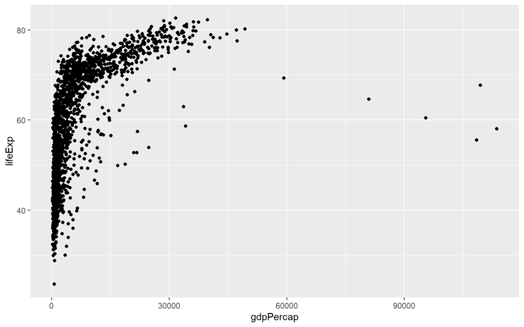

```r
# Make a plot object
p <- ggplot(data = gapminder,
            mapping = aes(x = gdpPercap,
                          y = lifeExp))

# Create a scatterplot
p + geom_point()
```

## Make a Plot

`ggplot2` is an `R` library/package that allows us to map data to visual elements. Using it we can control the way the data appears in the plot and how each element of the plot will be displayed. **Aesthetic Mappings** make the connection between the data and how it is displayed on the plot (location, size, color, shape, etc.). **Geoms** define the type of plot (scatterplot, line plot, box plot, bar chart, etc.). Code is added together to make the plot using `+` the plus sign. More pieces can be added to the plot that define the scales, legend, labels, axes, style or theme of the plot, etc. Each part can be added using different functions with arguments specifying the look of the plot; the plot is built up piece by piece.

### Tidy Data

In tidy data:  
1. Each variable forms a column.  
2. Each observation forms a row.  
3. Each type of observational unit forms a table.

From Wickham, H. (2014). Tidy Data. *Journal of Statistical Software*, 59(10).

### Mapping

Build a plot layer by layer, starting with telling ggplot what data to use and how to map or link it to parts of the plot, like the x and y axes. Then add on the type of `geom`.

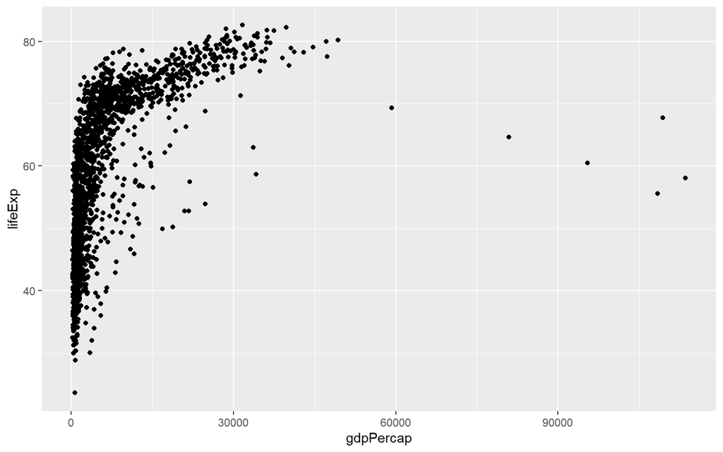

```r
p <- ggplot(data = gapminder,
              mapping = aes(x = gdpPercap,
                            y = lifeExp))

  p + geom_point()
```

### Layer by Layer

Trying different `geom_` functions.

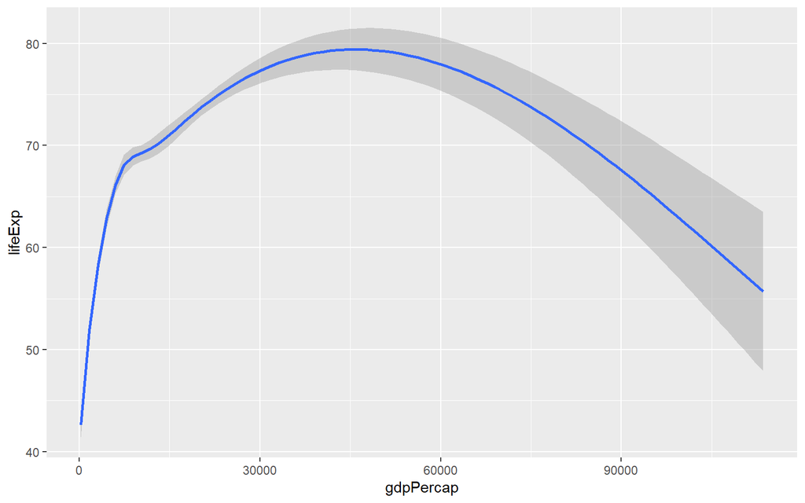

```r
p <- ggplot(data = gapminder,
            mapping = aes(x = gdpPercap,
                          y = lifeExp))

p + geom_smooth()
```

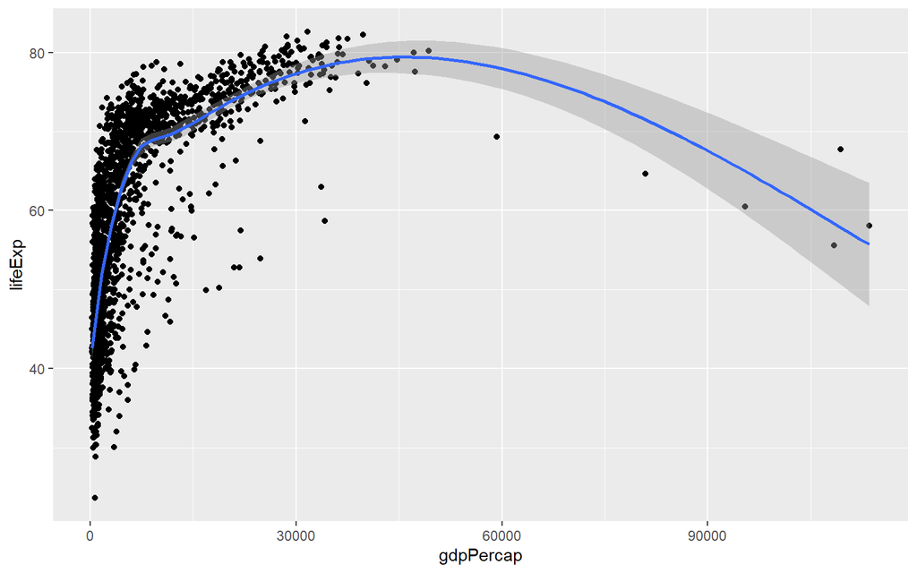

```r
p + geom_point() + # add the points back into the plot
  geom_smooth()
```

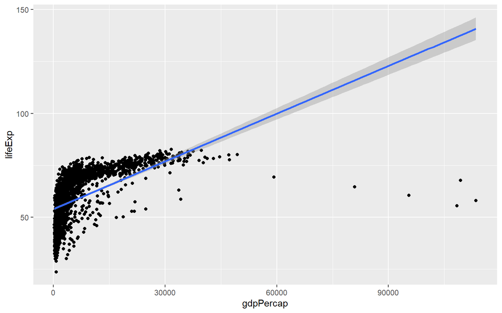

```r
p + geom_point() +
  geom_smooth(method = "lm") # use a linear model
```

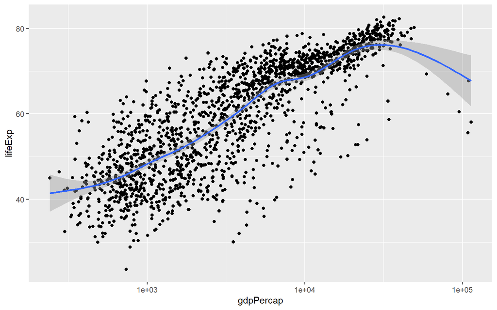

```r
p + geom_point() +
  geom_smooth(method = "gam") + # generalized additive model
  scale_x_log10() # transform x-axis to log-10 scale
```

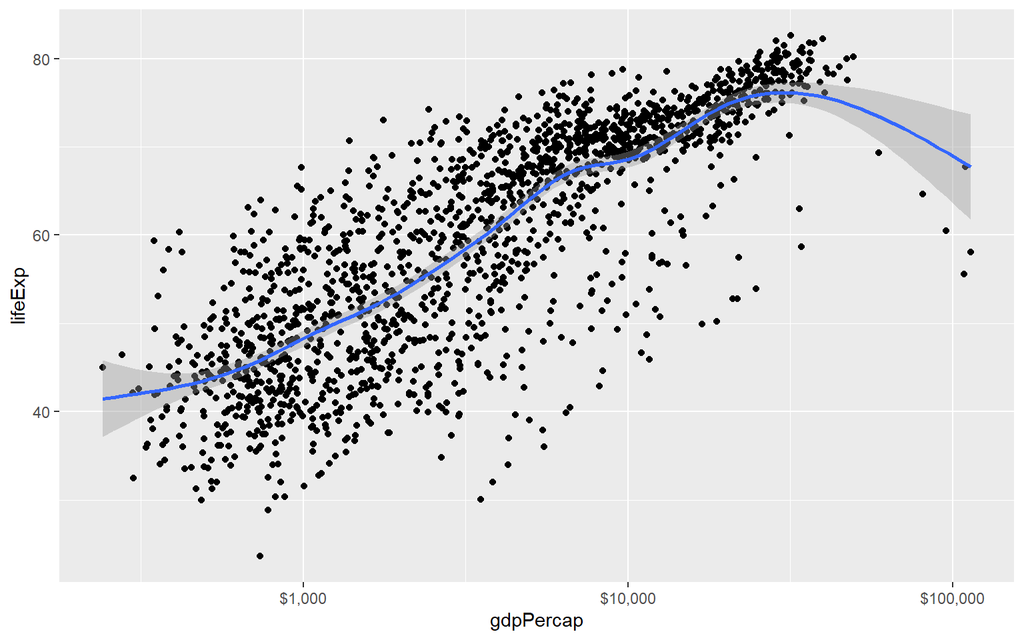

```r
p + geom_point() +
  geom_smooth(method = "gam") +
  scale_x_log10(labels = scales::dollar) # format x-axis in dollars
```

### Mapping Aesthetics

Using the aesthetics mapping, different parts of the data can be encoded in different ways.

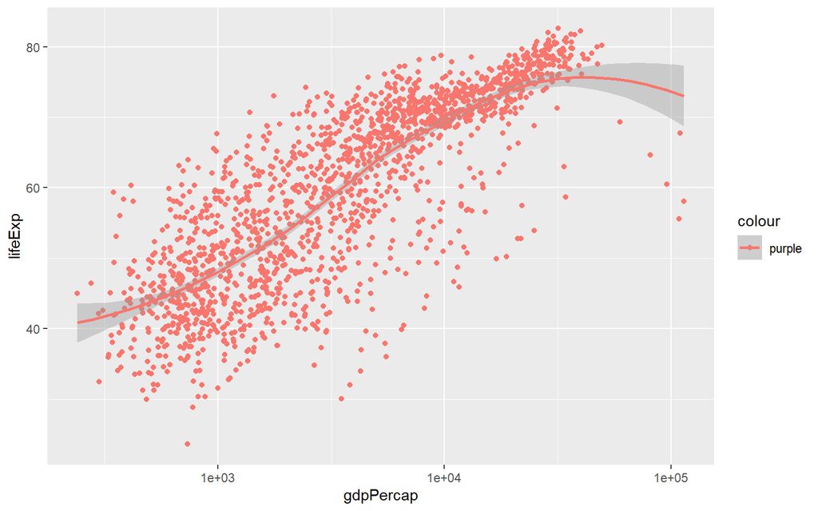

```r
p <- ggplot(data = gapminder,
            mapping = aes(x = gdpPercap,
                          y = lifeExp,
                          color = "purple")) # ggplot adds the value "purple" to all rows

p + geom_point() +
  geom_smooth(method = "loess") +
  scale_x_log10()
```

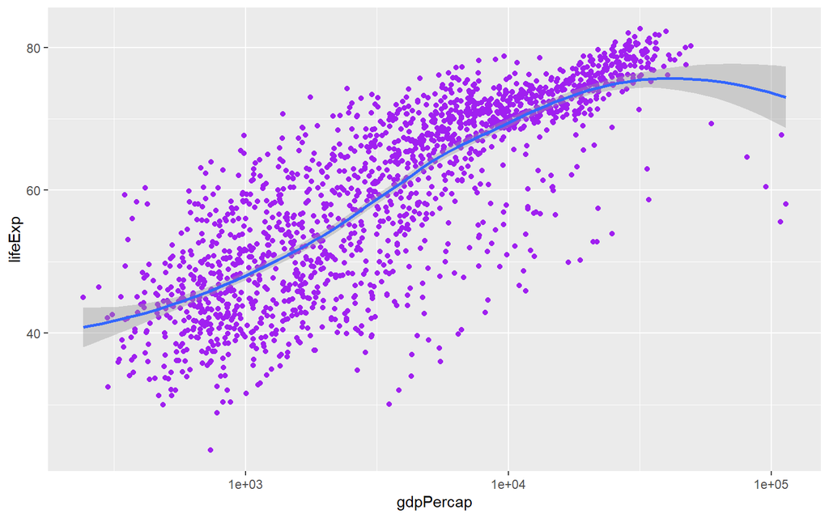

```r
# To actually turn all of the points purple, we need to set the color property of the geom_ function

p <- ggplot(data = gapminder,
            mapping = aes(x = gdpPercap,
                          y = lifeExp))

p + geom_point(color = "purple") + # set point color to purple
  geom_smooth(method = "loess") +
  scale_x_log10()
```

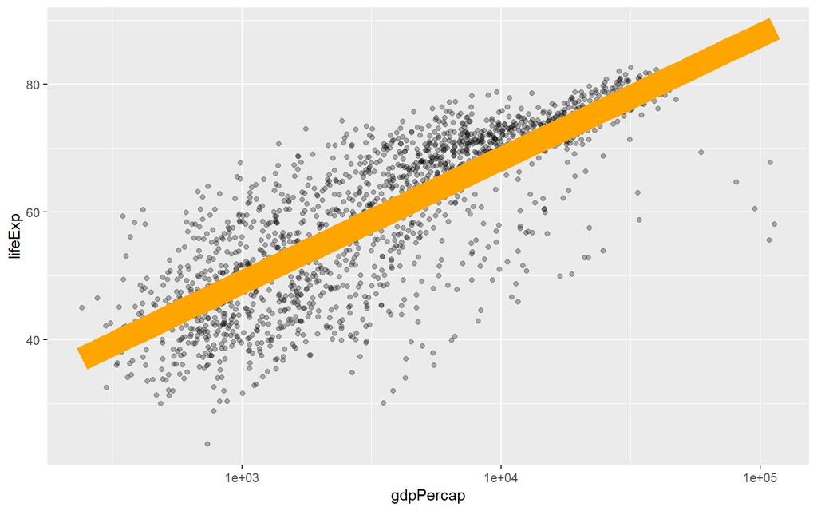

```r
p + geom_point(alpha = 0.3) + # make points more transparent
  geom_smooth(color = "orange", # make line orange
              se = FALSE, # remove standard error band
              size = 8, # increase thickness of the line
              method = "lm") +
  scale_x_log10()
```

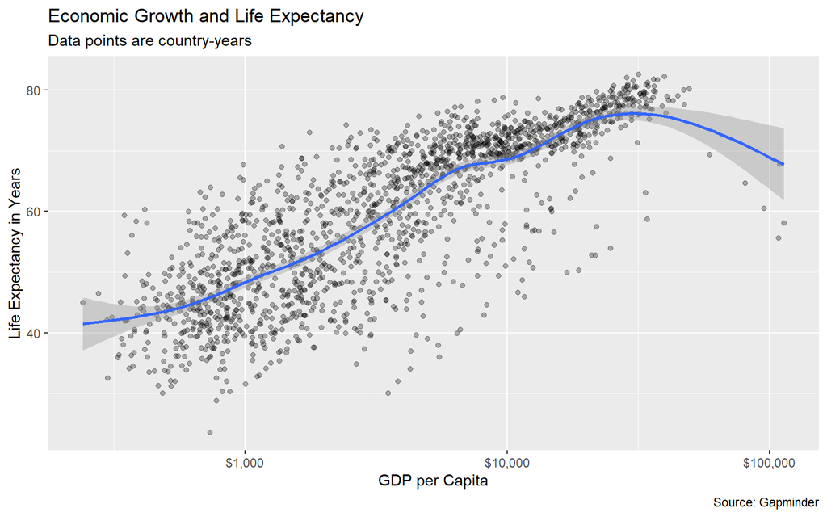

```r
p + geom_point(alpha = 0.3) + # make points more transparent
  geom_smooth(method = "gam") +
  scale_x_log10(labels = scales::dollar) +
  # Add title and labels
  labs(x = "GDP per Capita",
       y = "Life Expectancy in Years",
       title = "Economic Growth and Life Expectancy",
       subtitle = "Data points are country-years",
       caption = "Source: Gapminder")
```

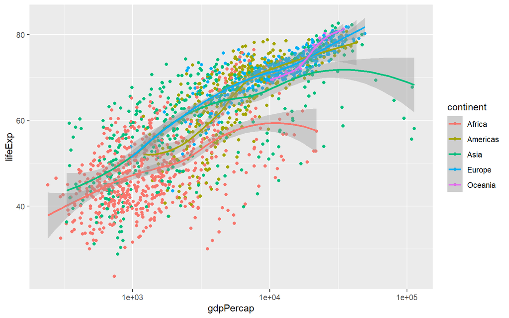

```r
# Map data by continent
p <- ggplot(data = gapminder,
            mapping = aes(x = gdpPercap,
                          y = lifeExp,
                          color = continent))

p + geom_point() +
  geom_smooth(method = "loess") +
  scale_x_log10()
```

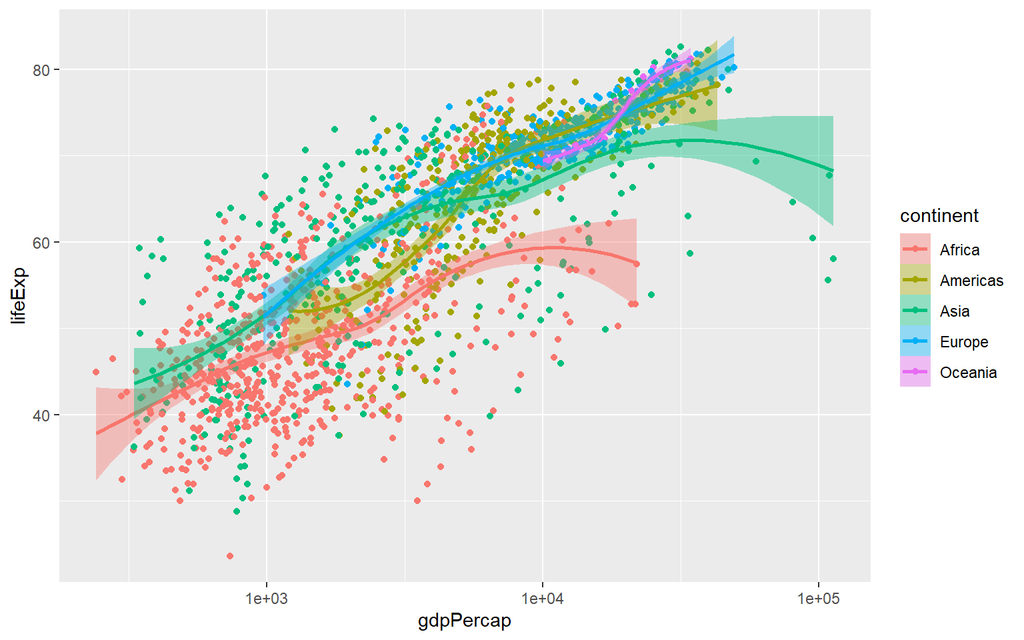

```r
p <- ggplot(data = gapminder,
            mapping = aes(x = gdpPercap,
                          y = lifeExp,
                          color = continent,
                          fill = continent)) # now the error bands will also have the color

p + geom_point() +
  geom_smooth(method = "loess") +
  scale_x_log10()
```

### Aesthetics by Geom

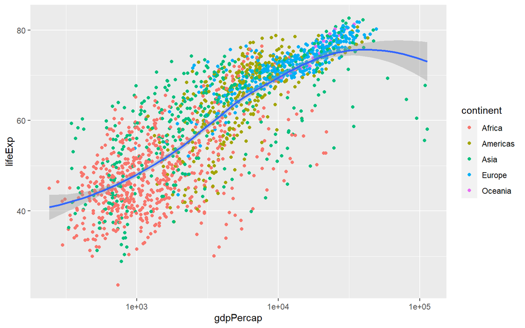

```r
p <- ggplot(data = gapminder,
            mapping = aes(x = gdpPercap,
                          y = lifeExp))

p + geom_point(mapping = aes(color = continent)) + # points will be colored by continent
  geom_smooth(method = "loess") + # the smoothed line will be for all data
  scale_x_log10()
```

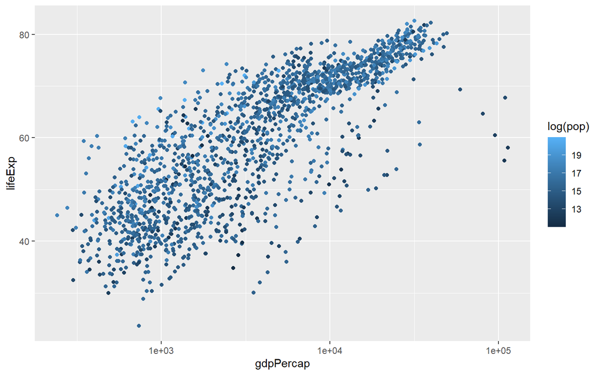

```r
p + geom_point(mapping = aes(color = log(pop))) + # points will be colored by population
  scale_x_log10()
```

### Saving

Use `here()` to save plots in the current directory. This function can also be used to reference folders within the current directory. For this class, use `.svg` to save in vector format and embed in Adobe Illustrator. The function to save a plot is `ggsave()` which will automatically save the last plot and can also be provided a `ggplot` object to save.

### Where to Go Next

Pick at least two of the questions presented under the *Where to Go Next* section and answer them.

## Show the Right Numbers

## Graph Tables, Make Labels, Add Notes

## Work with Models

## Draw Maps

## Refine your Plots